# Iris

### use load_iris to load data from scikit-learn

the object type is Bunch, which is very similar to dictionary, has key and value.

```python
from sklearn.datasets import load_iris
import pandas as pd
import numpy as np
iris_dataset = load_iris()
```

```python
print("Keys of iris_dataset: \n{}".format(iris_dataset.keys()))
```

```
Keys of iris_dataset:
dict_keys(['data', 'target', 'target_names', 'DESCR', 'feature_names', 'filename'])
```

DESCR has the description of the dataset

```python
print(iris_dataset['DESCR'][:193] + "\n...")
```

```
.. _iris_dataset:

Iris plants dataset
--------------------

**Data Set Characteristics:**

    :Number of Instances: 150 (50 in each of three classes)
    :Number of Attributes: 4 numeric, pre
...
```

The records in the dataset called sample, and the variable it has named features. The shape of the data equal to number of sample * number of features

```python
print("Shape of data: {}".format(iris_dataset['data'].shape))
print("Feature names: \n{}".format(iris_dataset['feature_names']))
print("First five rows of data:\n{}".format(iris_dataset['data'][:5]))
```

```
Shape of data: (150, 4)
Feature names:
['sepal length (cm)', 'sepal width (cm)', 'petal length (cm)', 'petal width (cm)']
First five rows of data:
[[5.1 3.5 1.4 0.2]
 [4.9 3.  1.4 0.2]
 [4.7 3.2 1.3 0.2]
 [4.6 3.1 1.5 0.2]
 [5.  3.6 1.4 0.2]]
```

#### Using train_test_split function to split dataset into training (75%) and testing (25%) data.

```python
from sklearn.model_selection import train_test_split
X_train, X_test, y_train, y_test = train_test_split(
iris_dataset['data'], iris_dataset['target'], random_state=0)
print("X_train shape: {}".format(X_train.shape))
print("X_test shape: {}".format(X_test.shape))
```

```
X_train shape: (112, 4)
X_test shape: (38, 4)
```

Before analyzing, we need to check our dataset. One of the best ways of checking is visualization. We could represent either a scatter plot or a pair plot. For rendering a pair plot, we could use the following function

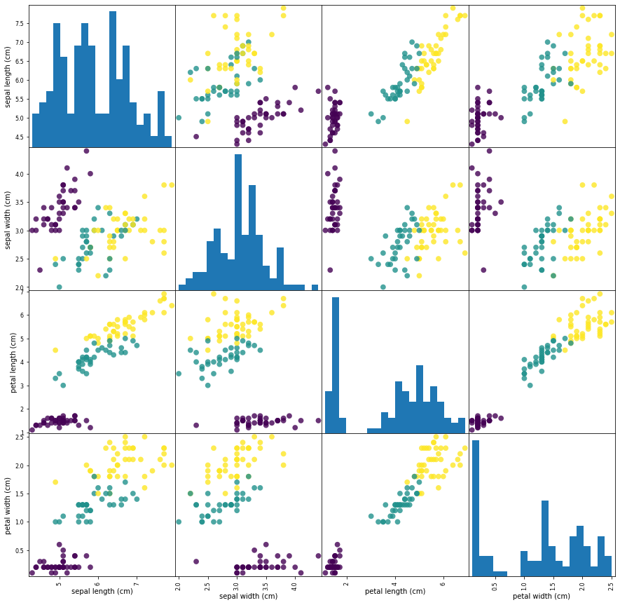

```python
iris_dataframe = pd.DataFrame(X_train, columns=iris_dataset.feature_names)
grr = pd.plotting.scatter_matrix(iris_dataframe, c=y_train, figsize=(15, 15), marker='o',
                       hist_kwds={'bins': 20}, s=60, alpha=.8)
```

### First Model : K-nearest neighborhood

The most important parameter in this model is number of neighbors to be refered, Here we set it as 5

```python
from sklearn.neighbors import KNeighborsClassifier
### set the parameter
knn = KNeighborsClassifier(n_neighbors=5)
```

#### Knn object Encapsulate the algorithm of KNN, if we want to build a model from it, using fit function

knn.fit(X_train, y_train)

```python
knn.fit(X_train, y_train)
```

```
KNeighborsClassifier(algorithm='auto', leaf_size=30, metric='minkowski',
                     metric_params=None, n_jobs=None, n_neighbors=5, p=2,
                     weights='uniform')
```

#### Make the prediction

We found a new iris which has sepal length as 5, sepal width as 2.9, petal length as 1, petal width as 0.2

```python
X_new = np.array([[5, 2.9, 1, 0.2]])
print("X_new.shape: {}".format(X_new.shape))
```

```
X_new.shape: (1, 4)
```

```python
prediction = knn.predict(X_new)
print("Prediction: {}".format(prediction))
print("Predicted target name: {}".format(
iris_dataset['target_names'][prediction]))
```

```
Prediction: [0]
Predicted target name: ['setosa']
```

#### Evaluate Model

Using testing dataset to calculate the accuracy of our model

```python
y_pred = knn.predict(X_test)
print("Test set predictions:\n {}".format(y_pred))
```

```
Test set predictions:
 [2 1 0 2 0 2 0 1 1 1 2 1 1 1 1 0 1 1 0 0 2 1 0 0 2 0 0 1 1 0 2 1 0 2 2 1 0
 2]
```

```python
print("Test set score: {:.2f}".format(np.mean(y_pred == y_test)))
```

```
Test set score: 0.97
```

#### We could also use score function in knn object, which is same as the above algorithm

```python
print("Test set score: {:.2f}".format(knn.score(X_test, y_test)))
```

```
Test set score: 0.97
```

### Fit, Predict, Score are most frequency functions would be used in Machine learning